# Image Pyramids

```python
import cv2
import numpy as np
import matplotlib.pyplot as plt

def show_image(img, ax=None, title="", bgr=True):
    # since plt and cv2 have different RGB sorting
    if bgr:
        img = cv2.cvtColor(img,cv2.COLOR_BGR2RGB)
    if ax == None:
        plt.figure(figsize=(4, 4))
        plt.imshow(img.astype(np.uint8))
        plt.axis("off")
        plt.title(title)
    else:
        ax.imshow(img.astype(np.uint8))
        ax.set_axis_off()
        ax.set_title(title)
```

## Image Downsampling

#### Initial thought

To resize of image to $\frac{1}{n}$, resample the image by picking pixel per $n$ pixels

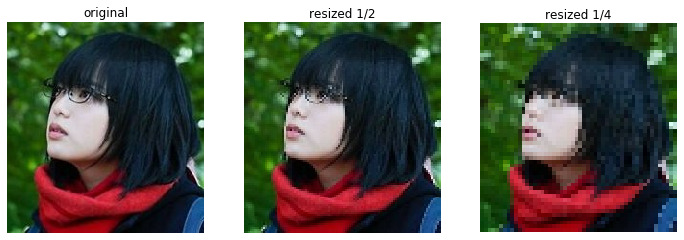

```python
img = cv2.imread("../assets/yurina.jpg")
fig, axs = plt.subplots(1, 3, figsize=(12, 4))
show_image(img, axs[0], title="original")
show_image(img[::2, ::2], axs[1], title="resized 1/2")
show_image(img[::4, ::4], axs[2], title="resized 1/4")
```

#### Problem: Aliasing

Occurs when sampling rate is not high enough to capture the amount of detail in the image.

Below is an extremum, which we lost half of the important information

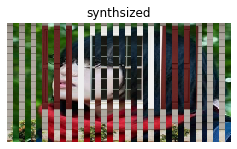

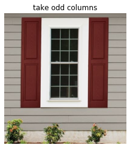

```python
img2 = cv2.imread("../assets/window.jpg")
img2 = cv2.resize(img2, (img.shape[1], img.shape[0]))
img3 = np.empty((img2.shape[0], img2.shape[1]*2, 3), dtype=np.uint8)
for i in range(img.shape[1]):
    img3[:, 2*i] = img2[:, i]
    img3[:, 2*i+1] = img[:, i]
show_image(img3, title="synthsized")
show_image(img3[:, ::2], title="take odd columns")
```

#### Nyquist rate

To avoid such aliasing issue, one should sample at least $2\times \max{f}$, i.e. at least twice the highest frequency.

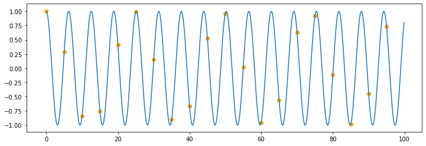

```python
plt.figure(figsize=(12, 4))
x = np.arange(0, 100, 0.1)
x2 = np.arange(0, 100, 5)
plt.plot(x, np.cos(x))
plt.scatter(x2, np.cos(x2), color="orange");
```

With twice the frequency, we can make sure the information is caught, while in other cases, it might not be true

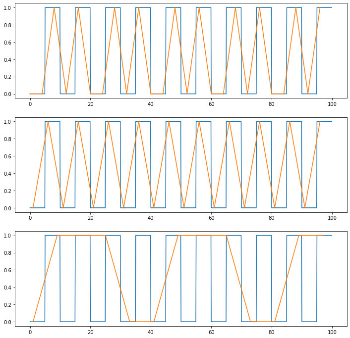

```python
x = np.arange(0, 100, 0.1)
y = np.remainder(x, 10) >= 5

x_sample4 = np.arange(0, 100, 4)
y_sample4 = np.remainder(x_sample4, 10) >= 5

x_sample5 = np.arange(1, 100, 5)
y_sample5 = np.remainder(x_sample5, 10) >= 5

x_sample8 = np.arange(1, 100, 8)
y_sample8 = np.remainder(x_sample8, 10) >= 5

fig, axs = plt.subplots(3, figsize=(12, 12))
for i in range(3):
    axs[i].plot(x, y)
axs[0].plot(x_sample4, y_sample4)
axs[1].plot(x_sample5, y_sample5)
axs[2].plot(x_sample8, y_sample8);
```

#### Gaussian pre-filtering

When downsampling, the original image has too high frequencies, results in information loss. The high frequencies are caused by shape edges, hence we can smooth the image to filter out high frequencies, with a low-pass filter

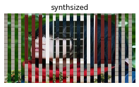

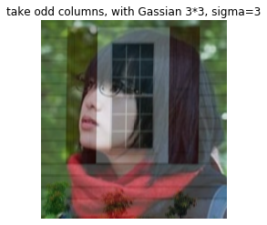

```python
img3_g = cv2.GaussianBlur(img3, (3, 3), 3)[:, ::2]
show_image(img3, title="synthsized")
show_image(img3_g, title="take odd columns, with Gassian 3*3, sigma=3")
```

#### Gaussian Pyramids

A sequence of images created with Gaussian blurring and downsampling is called a **Gaussian pyramid** or mip map

## Image Up-Sampling

#### Interpolation

Since an image is a discrete point-sampling of a continuous function, i.e. $F(x,y) = quantize\{f(x/d, y/d)\}$. If we could somehow reconstruct the original continuous function, we can generate the image with any resolution and scale.

However, we are unable to obtain such $f$, but we can guess an approximation

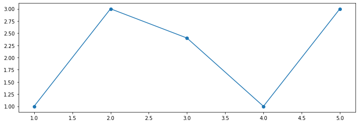

```python
sample_x = np.arange(1, 6)
sample_y = np.array([1, 3, 2.4, 1, 3])
plt.figure(figsize=(12, 4))
plt.scatter(sample_x, sample_y)
plt.plot(sample_x, sample_y);
```

**Nearest neighbor** $f(x) = F(arg\min\{d(x - x_i)\})$

#### Linear interpolation

Given $x \in [x_i, x_{i+1}], G(x) = \frac{x_{i+1}-x}{x_{i+1}-x_i}F(x_i) + \frac{x-x_{i+1}}{x_{i+1}-x_i}F(x_{i+1})$

##### via Convolution 1D

To upsampling a line $F= p_1, p_2, ..., p_n$,  
insert $n*0$s between $p_i, p_{i+1}$, make into $G = p_i. 0, 0, ..., 0, p_{i+1}$  
Take convolution filter $h = [0, 1/d, 2/d, ..., d/d, (d-1)/d, ... 0]$  
$h*G$ is desired

Similar idea goes to 2D